# Final Project

## Completing Table 3

```python
#run all of the models with the holdout data
knn_pred_scaled, knn_probs_scaled = knn(X_train_holdout_scaled, X_test_pixels_scaled, y_train_holdout, y_test_pixels)
lda_pred_scaled, lda_probs_scaled = lda(X_train_holdout_scaled, X_test_pixels_scaled, y_train_holdout, y_test_pixels)
qda_pred_scaled, qda_probs_scaled = qda(X_train_holdout_scaled, X_test_pixels_scaled, y_train_holdout, y_test_pixels)
logreg_pred_scaled, logreg_probs_scaled = logistic_regression(X_train_holdout_scaled, X_test_pixels_scaled, y_train_holdout, y_test_pixels)
```

```
KNN performs best when the classifier k=25
```

#### Accuracy

```python
def accuracy(y_test, pred, method):
    accuracy = accuracy_score(y_test, pred)
    print('{} Accuracy: {}'.format(method,str(accuracy)))
    print('{} Test Error: {}'.format(method, str(1 - accuracy )))
    """that's actually not very helpful because this is scoring across classes, which
    isn't giving us a good view of the accuracy of the model...use this instead:"""

    return accuracy
    # ^^ there is a severe imbalance
    #https://machinelearningmastery.com/threshold-moving-for-imbalanced-classification/
    #need to move threshold to accommodate this imbalance
    #"It has been stated that trying other methods, such as sampling, without trying by simply setting the threshold may be misleading. The threshold-moving method uses the original training set to train [a model] and then moves the decision threshold such that the minority class examples are easier to be predicted correctly."
    #Pages 72, Imbalanced Learning: Foundations, Algorithms, and Applications, 2013.


    #rfc_holdout, X_train_holdout_scaled, y_train_holdout, y_test_pixels, bagging_pred_holdout
    X_test_holdout_scaled
knn_accuracy = accuracy(y_test_pixels,knn_pred_scaled,'KNN')
lda_accuracy = accuracy(y_test_pixels,lda_pred_scaled,'LDA')
qda_accuracy = accuracy(y_test_pixels,qda_pred_scaled,'QDA')
logreg_accuracy = accuracy(y_test_pixels,logreg_pred_scaled,'Logistic Regression')
bagging_accuracy = accuracy(y_test_pixels, bagging_pred_holdout,'Bagging')
svm_accuracy = accuracy(y_test_downsampled_holdout, clf_svm_pred_downsampled, 'SVM')
```

```
KNN Accuracy: 0.9921411742382316
KNN Test Error: 0.00785882576176844
LDA Accuracy: 0.9851994750241141
LDA Test Error: 0.01480052497588591
QDA Accuracy: 0.9895162948087475
QDA Test Error: 0.010483705191252524
Logistic Regression Accuracy: 0.9895321073354312
Logistic Regression Test Error: 0.010467892664568823
Bagging Accuracy: 0.9902594835628785
Bagging Test Error: 0.009740516437121483
SVM Accuracy: 0.9925
SVM Test Error: 0.007499999999999951
```

#### AUC

We can then use the roc_auc_score() function to calculate the true-positive rate and false-positive rate for the predictions using a set of thresholds that can then be used to create a ROC Curve plot.

```python
def calculate_AUC(y_test, prob):
    # calculate scores
    auc = roc_auc_score(y_test, prob)
    return auc

auc_KNN = calculate_AUC(y_test_pixels, knn_pred_scaled)
print('auc_KNN:', auc_KNN)
auc_LDA = calculate_AUC(y_test_pixels, lda_pred_scaled)
print('auc_QDA:',auc_LDA)
auc_QDA = calculate_AUC(y_test_pixels, qda_pred_scaled)
print('auc_QDA:', auc_QDA)
auc_LogisticRegression = calculate_AUC(y_test_pixels, logreg_pred_scaled)
print('auc_LogisticRegression:',auc_LogisticRegression)
auc_Bagging = calculate_AUC(y_test_pixels, bagging_pred_holdout)
print('auc_Bagging:',auc_Bagging)
auc_SVM = calculate_AUC(y_test_downsampled_holdout, clf_svm_pred_downsampled)
print('auc_SVM:',auc_SVM)
```

```
auc_KNN: 0.8792538920241414
auc_QDA: 0.8732772786400994
auc_QDA: 0.836053412462908
auc_LogisticRegression: 0.8363006923837784
auc_Bagging: 0.8488711313531196
auc_SVM: 0.9928909952606635
```

#### ROC

```
Best Threshold=0.040000
```

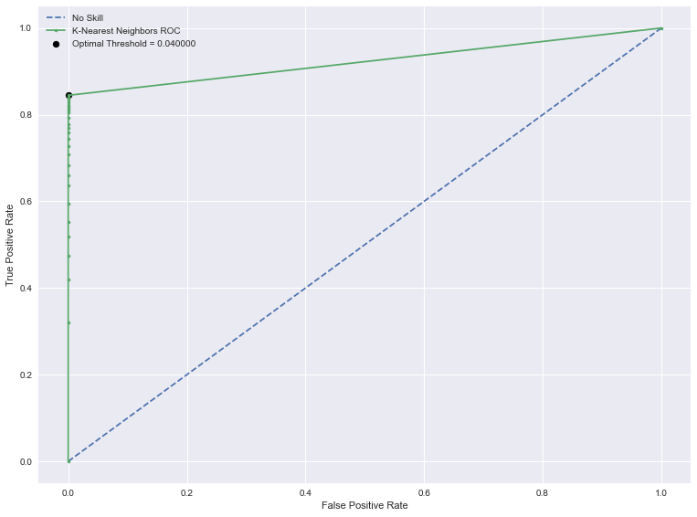

```python
roc_KNN = calculate_ROC(y_test_pixels, knn_probs_scaled, Type='K-Nearest Neighbors')
```

```
Best Threshold=0.000265
```

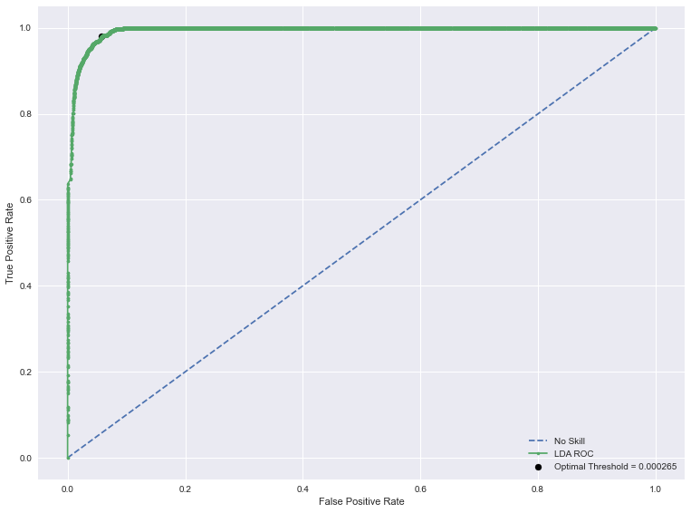

```python
roc_LDA = calculate_ROC(y_test_pixels, lda_probs_scaled, Type='LDA')
```

```
Best Threshold=0.001318
```

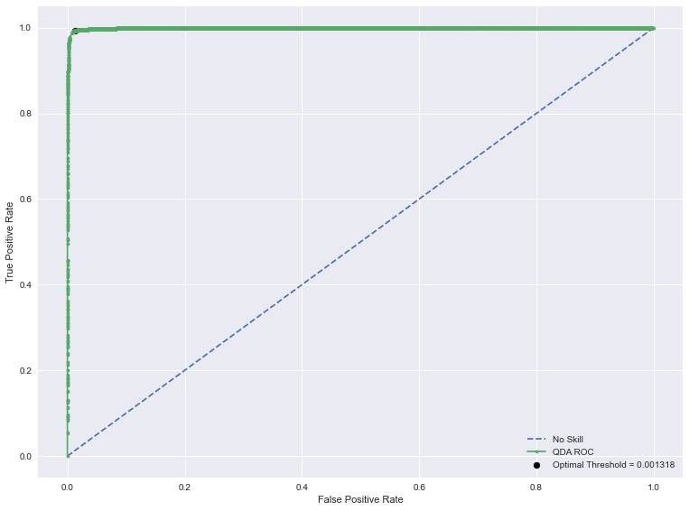

```python
roc_QDA = calculate_ROC(y_test_pixels, qda_probs_scaled, Type='QDA')
```

```
Best Threshold=0.000727
```

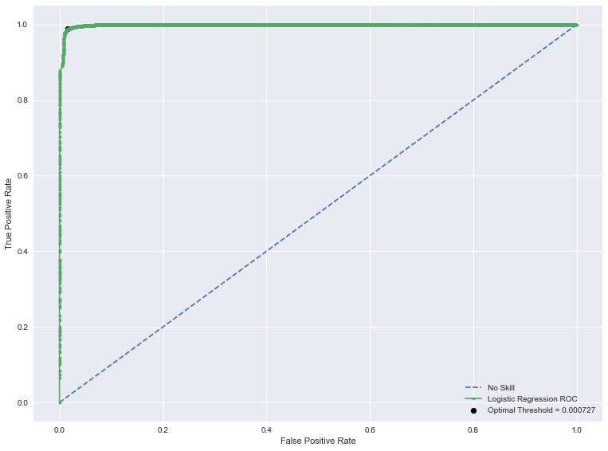

```python
roc_LogisticRegression = calculate_ROC(y_test_pixels, logreg_probs_scaled,Type='Logistic Regression')
```

```
Best Threshold=0.003679
```

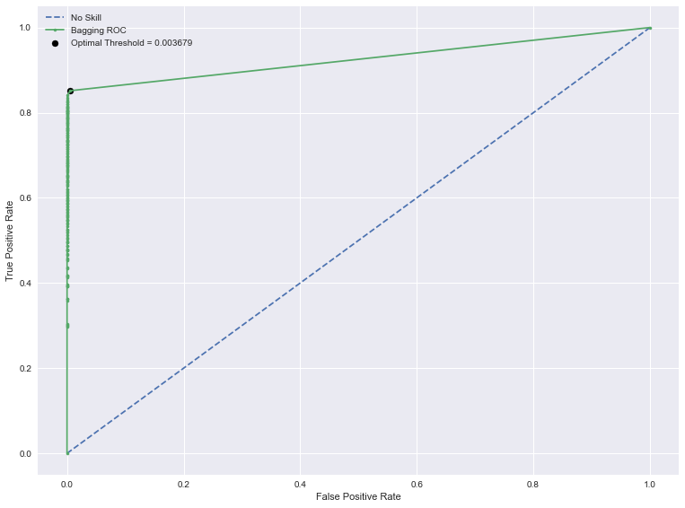

```python
roc_Bagging = calculate_ROC(y_test_pixels, bagging_probs_holdout,Type='Bagging')
```

```
Best Threshold=0.209021
```

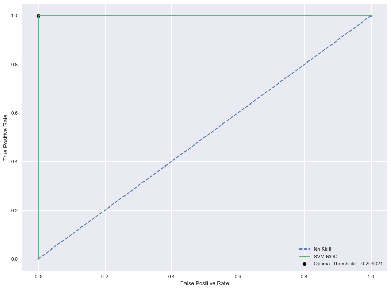

```python
roc_SVM = calculate_ROC(y_test_downsampled_holdout, clf_svm_probs_downsampled,Type='SVM')
```

#### Confusion Matrix

```python
len(y_test_pixels), len(knn_pred),y_test_pixels,knn_pred
```

```
(63241,
 6324,
 0        0
 1        0
 2        0
 3        0
 4        0
         ..
 63236    1
 63237    1
 63238    1
 63239    1
 63240    1
 Name: Class, Length: 63241, dtype: int64,
 array([0, 0, 0, ..., 1, 1, 1]))
```

```python
#KNN
knn_confusion_matrix = conf_m(y_test_pixels,knn_pred_scaled)

print('\n')

tn = 61210
fp = 9
fn = 488
tp = 1534

sensitivity = tp / (tp + fn)
specificity = tn / (tn + fp)
fpr = 1-specificity
precision = tp / (tp + fp)

print('sensitivity:',sensitivity)
print('specificity:',specificity)
print('fpr:',fpr)
print('precision:',precision)
```

```
Predicted      0     1
True
0          61210     9
1            488  1534


sensitivity: 0.7586547972304649
specificity: 0.999852986817818
fpr: 0.00014701318218202086
precision: 0.9941672067401166
```

```python
#LDA
lda_confusion_matrix = conf_m(y_test_pixels,lda_pred_scaled)

print('\n')

tn = 60781
fp = 438
fn = 498
tp = 1524

sensitivity = tp / (tp + fn)
specificity = tn / (tn + fp)
fpr = 1-specificity
precision = tp / (tp + fp)

print('sensitivity:',sensitivity)
print('specificity:',specificity)
print('fpr:',fpr)
print('precision:',precision)
```

```
Predicted      0     1
True
0          60781   438
1            498  1524


sensitivity: 0.7537091988130564
specificity: 0.9928453584671425
fpr: 0.0071546415328574975
precision: 0.7767584097859327
```

```python
#QDA
qda_confusion_matrix = conf_m(y_test_pixels,qda_pred_scaled)

print('\n')

tn = 61219
fp = 0
fn = 663
tp = 1359

sensitivity = tp / (tp + fn)
specificity = tn / (tn + fp)
fpr = 1-specificity
precision = tp / (tp + fp)

print('sensitivity:',sensitivity)
print('specificity:',specificity)
print('fpr:',fpr)
print('precision:',precision)
```

```
Predicted      0     1
True
0          61219     0
1            663  1359


sensitivity: 0.672106824925816
specificity: 1.0
fpr: 0.0
precision: 1.0
```

```python
#Logistic Regression
logistic_regression_confusion_matrix = conf_m(y_test_pixels,logreg_pred_scaled)

print('\n')

tn = 61219
fp = 0
fn = 662
tp = 1360

sensitivity = tp / (tp + fn)
specificity = tn / (tn + fp)
fpr = 1-specificity
precision = tp / (tp + fp)

print('sensitivity:',sensitivity)
print('specificity:',specificity)
print('fpr:',fpr)
print('precision:',precision)
```

```
Predicted      0     1
True
0          61219     0
1            662  1360


sensitivity: 0.6726013847675568
specificity: 1.0
fpr: 0.0
precision: 1.0
```

```python
#Bagging
bagging_confusion_matrix = conf_m(y_test_pixels,bagging_pred_holdout)

print('\n')

tn = 61214
fp = 5
fn = 611
tp = 1411

sensitivity = tp / (tp + fn)
specificity = tn / (tn + fp)
fpr = 1-specificity
precision = tp / (tp + fp)

print('sensitivity:',sensitivity)
print('specificity:',specificity)
print('fpr:',fpr)
print('precision:',precision)
```

```
Predicted      0     1
True
0          61214     5
1            611  1411


sensitivity: 0.6978239366963402
specificity: 0.9999183260098989
fpr: 8.167399010106102e-05
precision: 0.9964689265536724
```

```python
#SVM
svm_confusion_matrix = conf_m(y_test_downsampled_holdout, clf_svm_pred_downsampled)

print('\n')
tn = 189
fp = 0
fn = 3
tp = 208

sensitivity = tp / (tp + fn)
specificity = tn / (tn + fp)
fpr = 1-specificity
precision = tp / (tp + fp)

print('sensitivity:',sensitivity)
print('specificity:',specificity)
print('fpr:',fpr)
print('precision:',precision)
```

```
Predicted    0    1
True
0          189    0
1            3  208


sensitivity: 0.985781990521327
specificity: 1.0
fpr: 0.0
precision: 1.0
```

## Table 3

[output not shown]

# Conclusions

I moved away from the multiclass approach in this submission despite continuing to have a strong feeling that this is, in some capacity, the correct approach. The way I see it, looking at this as a binary classification problem is too simplistic. If the goal is to provide humanitarian aid to displaced people who have found temporary shelter under blue tarps, the misclassification between a blue tarp and a roof seems less severe than a blue tarp and a tree or a body of water. There has been an earthquake and we need to get aid to people, so if the misclassification points to a rooftop as a tarp, and we go to the rooftop, I would imagine there is a greater liklihood of someone being at the rooftop location (could be the rooftop of a house, where people live) is higher than the liklihood of finding someone under a misclassified tree or, even more ridiculously, a body of water. Unfortunately, this probabilistic model is beyond my current understanding.

- This blogpost on the Tensorflow website seems like the direction I'd like to take this project, but I just did not feel comfortable implementing a solution when I don't fully understand the math behind it. https://blog.tensorflow.org/2019/03/regression-with-probabilistic-layers-in.html.
- I do, however, think this Haiti Pixels project would be an interesting thing to come back to when I'm farther along in my program to see if I can apply some of the new methodologies to this problem and achieve the level of success I think is possible from this type of problem.

"Random forests tend to shine in scenarios where a model has a large number of features that individually have weak predicative power but much stronger power collectively." https://medium.com/@hjhuney/implementing-a-random-forest-classification-model-in-python-583891c99652

Random Forests reduce this variance by creating decision trees for many subsets of the data and then taking the average of all those decision trees. In a typical Random Forest, a random subset of the features are chosen for each decision tree. In a bagging model, all of the features are chosen for each decision tree.

If I had decided to go with the multiclass approach, I think that the Random Forest model would have been the optimal classification method. But since I ended up treating this as a binary classification problem, SVM makes more sense and ultimately performed better. The only thing holding SVM back is the computational burden of running the model on such a large dataset. I would recommend using the SVM model for this problem with the important caveat that there be sufficient processing power to actually run the entire dataset or at least a substantially larger percentage for the downsampled data than I used.

### Random Forest Hyperparameter Tuning

https://www.analyticsvidhya.com/blog/2020/03/beginners-guide-random-forest-hyperparameter-tuning/

This guide was instrumental in developing my understanding of which hyperparameters really matter when tuning a random forest model. Initially, my approach was to just throw a bunch of parameters into the param_grid and let the model identify the optimal parameters through the use of GridSearchCV. But this quickly proved to be unscalable. I tried upgrading this approach with RandomSearchCV but the big 2mil holdout dataset pummeled any hopes I had of using my original tuning function to fit the optimal random forest model. I needed to find a better solution to deal with large datasets.

In this guide from the analyticsvidhya.com article, I identified a few key parameters to focus on and learned how a much smaller range of options was necessary to pass to the gridsearch than I had initially thought. Here is a synopsis of my rationale for choosing the parameters that I did:

- **max_depth** determines the limit of the depth for each tree in the random forest. The performance of the model on training data increases continuously as max_depth increases because it gets closer and closer to a perfect fit of the data. Simultaneously, the fit on test data will decrease as max_depth increases since the model is overfit to the training data, and will thus perform poorly on the test data.
- **min_sample_split** determines the minimum number of observations for any node to split. By default this number is set to 2, which means that if any terminal node has more than two observations and is not a pure node, it can be split further into subnodes. As discussed above for max_depth, we want to avoid a random forest model comprised of trees with too many nodes, as that would indicate overfitting of the model. Leaving this min_sample_split number set to its default of 2 allows for this overfitting to occur, since 2 is so small and allows for trees to continue splitting until all the nodes are pure (1). "By increasing this number we can reduce the number of splits that happen in the decision tree and can thus prevent the model from overfitting" (or at least mitigate). However, it is important to not underfit this model (this is done by having the min_sample_split be too high, which would essentially lead to there being no significant splits observed, ultimately leading to a dip in both the training and test scores of model performance).
- **max_terminal_nodes / max_leaf_nodes** sets a condition on the splitting of the nodes in the tree, restricting the tree's growth. When the max_leaf_nodes is small, the random forest model will underfit.
- **min_samples_leaf** specifies the minimum number of samples that should be present in the leaf node after splitting a node. This is interesting to know but I'm not sure how helpful this will be in my model.
- **n_estimators** is super helpful for solving the exact problem I was having: as the number of trees used in the random forest model increases, so does the time complexity of the model. So, by limiting the n_estimators, we can control the time complexity from getting out of hand when working with large datasets.
- **max_samples** determines what fraction of the original dataset is given to any individual tree
- **max_features** determines the maximum number of features provided to each tree in the random forest model. The default value for this is set to the square root of the number of features present in the dataset. The ideal number of max_features generally tend to lie close to this value, so I will be leaving the max_features set to its default and will not be using it in the gridsearch.

### Concerns with using Bayesian modeling

Another idea I had to speed up the runtime was to use BayesSearchCV from scikit-optimize, which seemed promising at first but ended up not paning out the way I had hoped. First and foremost, I didn't feel comfortable implementing a solution when I did not fully understand the math behind it. Second, something about applying a Bayesian framework to a downsampled dataset seemed wrong to me. The idea of downsampling data is that you can apply the knowledge gained from a small subsample of a dataset and extrapolate the behavior seen in the subset to the larger dataset. And in this example, we are pushing that further by using the behavior seen in the holdout dataset to form conclusions about the pixels dataset. How could I, in good conscious, do this while using a theorem where the basic assumption is that your beliefs about data need to change when new data is available?

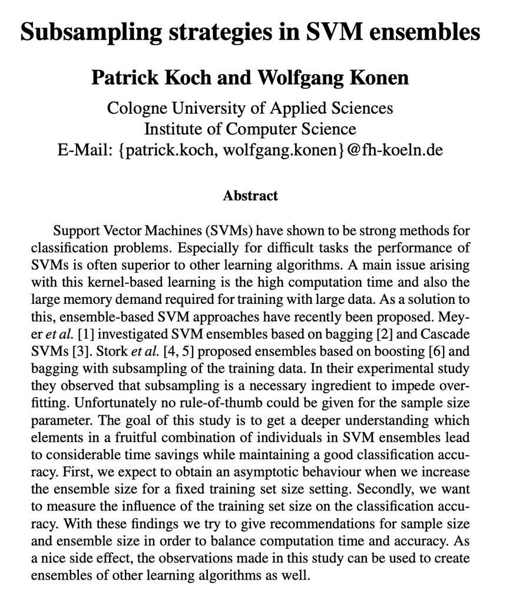

http://www.gm.fh-koeln.de/~konen/Publikationen/kochGMA2013.pdf

### Concerns with downsampling

After reading this paper on Subsampling Strategies in SVM models, my main question here is whether or not there will be degredation in the predictive capacity of our model if we use a subsample of the original data that is a substantially smaller percentage to the original (consider something like 1000 observations from the 2mil observation dataset).

This paper (in section 3 page 9) tests different percentages (10, 25, 50) and compares them to the whole, to see how well they perform. The authors report only a slight degredation alongside a substantial decrease in the computation time for the model, which is great news. The time complexity of running SVM on a large dataset is too taxing on my personal computer, so knowing that I can have confidence in the findings from my downsampled data (even if I'm using a very small percentage of the original data) is quite a relief. I am doing this project off of my laptop, which admittedly is pretty good, but I'm still only working with 6 cores and 32GB or RAM, so I can't afford to have a massively time and ddata intensive SVM run on my computer. I need speed because I need to be able to iterate quickly and determine the best model from the limited resources I have. So, downsampling my data must be the path forward since it offers me a "good enough" solution along with much improved computation times.

Something to consider here is the percentage that I'm using of the original holdout dataset. The paper I reference above mentions going as low as 10%, while I am going 0.1%. This is substantially less than discussed in the paper, so I may very well be taking such a small percentage of the dataset that I actually cannot trust the conclusions drawn from it because this is not a representative sample.